# [Back to Indexpage](http://henrikeckermann.pythonanywhere.com/)

###### Notes from the lecture:

- Standard error of estimate: Average prediction error (Interpretation in relation to the scale of DV)
- OLS is not iterative vs Maximum Likelihood method which is iterative
- $R^2:$ How much variation is explained by the predictor?
- coefficients
  - Unstandardized (b/B): By how many units does the DV increase if the predictor changes by one unit?
  - Standardized ($\beta$): By how many SD does the DV change if the predictor changes by one SD? Intercept = 0. For comparison with other LM.

###### Notes from books

- Use F-statistic and the associated p-value to answer: Is there a relationship between the p and Y? Because if you have 100 p, 5 will be significant on average (with p>0.05) if you look at the t-statistics. The F-statistic does take the number of p into account.
- Additive and linear assumption:
  - If $X_1$ increases, then Y increases by $b_1$ units, independent of $X_2, X_3, ...X_i$ (additive assumption) and it does so in a linear way, thus always by one unit for each unit increase in $X_1$ (linear assumption). In reality, it could be that if $X_1$ increases, that the slope $X_2$ changes as a consequence, thereby violating the additive assumption. This is called **synergy-** or **interaction** effect!
  - Can be modeled by interaction term (covariate). If you include covariates, then you should keep the main effects in the model, even if they are not significant.
- Error terms must be uncorrelated
- Homoscedasticity: Plot fitted values against standardized resdiuals and inspect for patterns such as typical *funnel* look indicating Homoscedasticity
- Outlier: Plot studentized residuals: More than 3SD deviation is considered a possible outlier here.
- Leverage: The leverage statistic $h_i$ is always between 1/n and 1, and the average leverage for all the observations is always equal to (p + 1)/n. We want to watch out for obersations that have more than 2x the average leverage (I indicate that in plots with a dashed line) when I plot leverage vs studentized resdiuals.
- Multicollinearity: Reduces accuracy of the estimates of regression coefficients
  - The **variance inflation factor (VIF)** is the ratio of the variance of $\hat\beta_j$ when fitting the full model divided by the variance of $\hat\beta_j$ on its own. The smalles possible VIF is 1. A rule of thumb: VIF>5 or 10 indicates problematic amount of collinearity.
  - If MC is present: Drop problematic variable or combine problematic variable into a single predictor
- Model accuracy: RSE, $R^2$, better: Cross Validation
- Model Fit: $MSE = \frac{1}{n}\sum_{i=1}^n(y_i - \hat{f}(x_i))^2$
  - Note: This will be only the *training MSE* here. I will cover e.g. Cross Validation in a separate Notebook or add it here later.
  - Root-MSE more interpretable and therefore more often used
  - Most important is the *test MSE*, which reflects how well our model reflects the real world.

```python
#import modules
from plotnine import *
import pandas as pd
import os
import statsmodels.api as sm
import statsmodels.formula.api as smf
import statsmodels.stats.api as sms
from statsmodels.compat import lzip
from statsmodels.stats.outliers_influence import OLSInfluence, variance_inflation_factor
import seaborn as sns
```

```python
#import data
data = pd.read_csv('REGRESSION.csv')
data = data.iloc[:,1:6]
data['index'] = data.index
data.head()
```

|  | id | timedrs | phyheal | menheal | stress | index |
| --- | --- | --- | --- | --- | --- | --- |
| 0 | 1 | 1 | 5 | 8 | 265 | 0 |
| 1 | 2 | 3 | 4 | 6 | 415 | 1 |
| 2 | 3 | 0 | 3 | 4 | 92 | 2 |
| 3 | 4 | 13 | 2 | 2 | 241 | 3 |
| 4 | 5 | 15 | 3 | 6 | 86 | 4 |

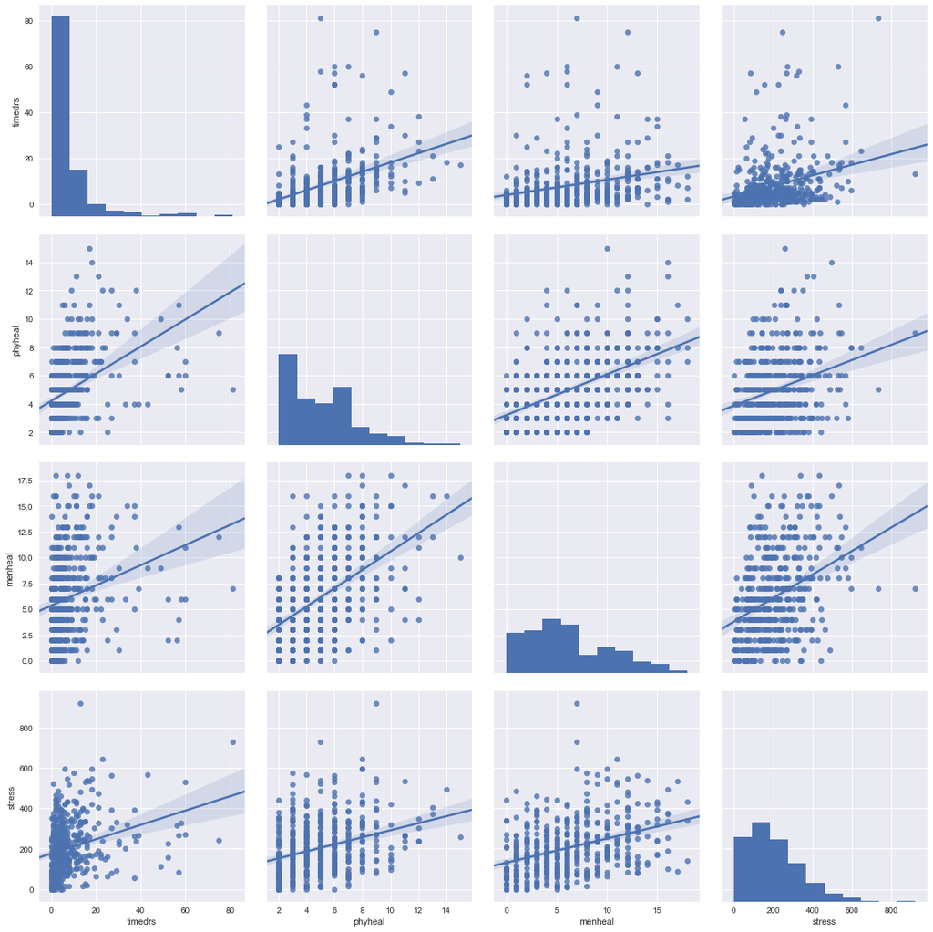

```python
# Quick look on relationship between X and Y
sns.pairplot(data.loc[:,['timedrs','phyheal','menheal','stress']], kind='reg', size=4)
```

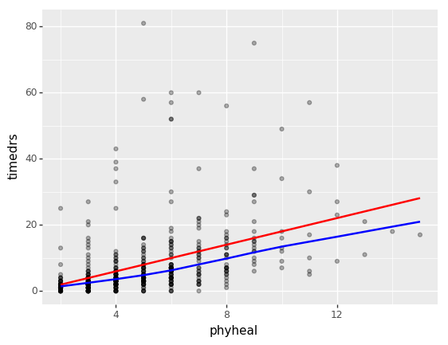

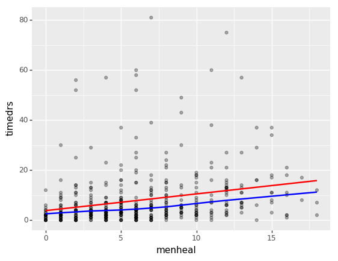

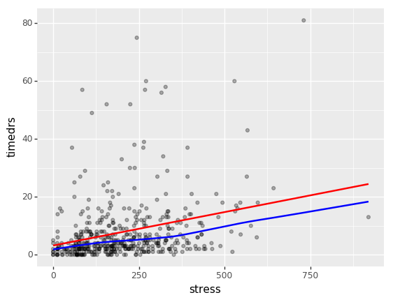

```python
#Alternatively, inspect the bivariate relationship between each X and y on separate plots including a LOESS Fit
for col in ['phyheal','menheal','stress']:
    print((ggplot(data, aes(x = col, y = 'timedrs'))
     + geom_point(alpha = 0.3)
     + geom_smooth(method = 'lm', color = 'red',se=False)
     + geom_smooth(color = 'blue',se=False)))
```

```python
#Fit regression models
results = smf.ols('timedrs ~ phyheal + menheal + stress', data=data).fit()

#Inspect results
results.summary()

#Add fitted values to data
data['fitted'] = results.fittedvalues
data['resid'] = results.resid
```

```python
#Append dataframe with stand-resid, stud-resid etc.
data = data.join(OLSInfluence(results).summary_frame())
outlier = data.loc[(data['standard_resid']>=2.5) | (data['standard_resid']<=-2.5)]
infl = data.loc[data.cooks_d>0.49,:]
```

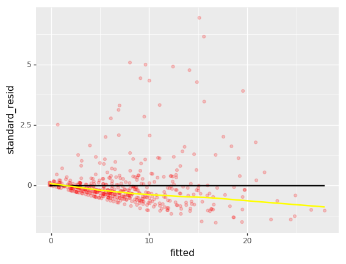

```python
#Inspect Heteroscesticity, Linearity and Normality visually
(ggplot(data, aes(x='fitted', y='standard_resid'))
+ geom_point(alpha=0.2, color='red')
+ geom_smooth(method='lm', color='black',se=False)
+ geom_smooth(color='yellow',se=False))
```

### Normality of the residuals

```python
#Normality of residuals
name = ['Jarque-Bera', 'Chi^2 two-tail prob.', 'Skew', 'Kurtosis']
test = sms.jarque_bera(results.resid)
lzip(name, test)
```

```
[('Jarque-Bera', 4899.275298594263),
 ('Chi^2 two-tail prob.', 0.0),
 ('Skew', 3.3365464224399055),
 ('Kurtosis', 17.433837110988318)]
```

```python
name = ['Chi^2', 'Two-tail probability']
test = sms.omni_normtest(results.resid)
lzip(name, test)
```

```
[('Chi^2', 357.90410177773151),
 ('Two-tail probability', 1.9147486574969422e-78)]
```

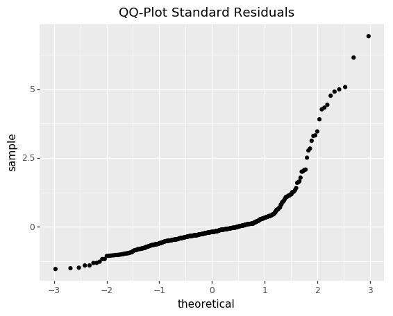

```python
(ggplot(data, aes(sample='standard_resid'))
+ geom_qq()
+ ggtitle('QQ-Plot Standard Residuals'))
```

### Influence tests

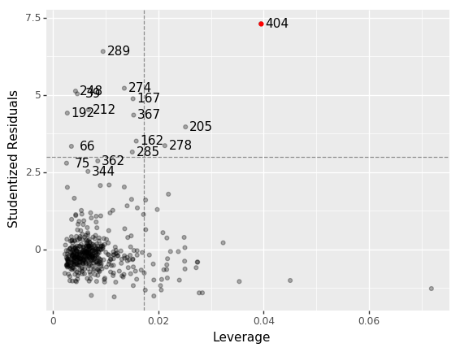

```python
#Create Influence plot
(ggplot(data, aes(x = 'hat_diag', y = 'student_resid'))
 + geom_point(alpha = 0.3)
 + geom_point(infl, aes(x = 'hat_diag', y = 'student_resid'), color = 'red')
 + geom_text(outlier, aes(label = 'index'), nudge_x = 0.003)
 + geom_vline(xintercept=2*data.hat_diag.mean(), linetype='dashed', alpha=0.4)
 + geom_hline(yintercept=3, alpha=0.4, linetype='dashed')
 + labs(x='Leverage', y='Studentized Residuals'))
```

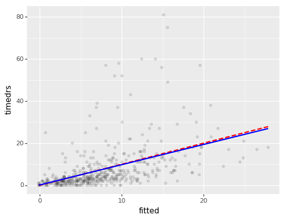

```python
outlier_rm = data.loc[data.student_resid<7,:]

(ggplot(data, aes(x='fitted',y='timedrs'))
 + geom_point(alpha=0.1)
 + geom_smooth(method='lm',se=False, color='red', linetype='dashed')
 + geom_smooth(aes(x='fitted',y='timedrs'),data=outlier_rm,method='lm',se=False, color='blue', alpha=0.4))
```

### Multicollinearity

```python
#np.linalg.cond(results.model.exog)
```

### Heteroscedasticity

The plot above clearly showed Heteroscedasticity. A test to quantify this is White’s Lagrange Multiplier test, the Breush-Pagan test (if the errors are normally distributed, which they are not here) or Goldfeld-Quandt test:

```python
name = ['Lagrange multiplier statistic', 'p-value',
        'f-value', 'f p-value']
test = sms.het_white(results.resid,results.model.exog)
lzip(name, test)
```

```
[('Lagrange multiplier statistic', 39.97328282309585),
 ('p-value', 7.6836835117827489e-06),
 ('f-value', 4.7546929141864585),
 ('f p-value', 4.5814126761595561e-06)]
```

```python
name = ['Lagrange multiplier statistic', 'p-value',
        'f-value', 'f p-value']
test = sms.het_breuschpagan(results.resid, results.model.exog)
lzip(name, test)
```

```
[('Lagrange multiplier statistic', 21.857594475647492),
 ('p-value', 6.983633449883957e-05),
 ('f-value', 7.5794680052119787),
 ('f p-value', 5.8722139573266083e-05)]
```

Goldfeld-Quandt test:

```python
name = ['F statistic', 'p-value']
test = sms.het_goldfeldquandt(results.resid, results.model.exog)
lzip(name, test)
```

```
[('F statistic', 1.2336566011714429), ('p-value', 0.056585659800230788)]
```

### Linearity

Plotting the standardized residuals against each predictor should show a random normally distributed residuals.

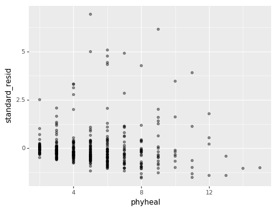

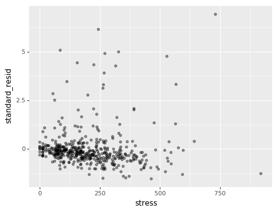

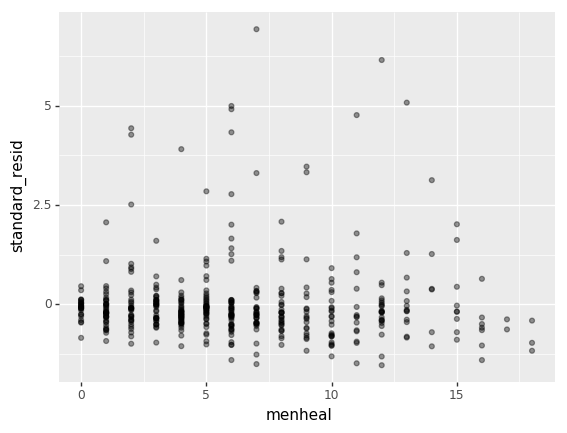

```python
for col in ['phyheal', 'stress', 'menheal']:
    print((ggplot(data, aes(x=col,y='standard_resid'))
    + geom_point(alpha=0.4)))
```

### Model Fit

If more than 1% of the absolute values of the standardized residuals are >= 2.5 or more than 5% >= 2, our model might be a poor fit for the data.

```python
p = np.mean(abs(data['standard_resid'])>=2)
pp = np.mean(abs(data['standard_resid'])>=2.5)
print('{:.3f}% 2.0 SD \n{:.3f}% 2.5 SD'.format(p*100,pp*100))
```

```
4.516% 2.0 SD
3.656% 2.5 SD
```

### Transform DV

```python
ldata = data.loc[:,['stress','menheal','phyheal']]
ldata['ltimedrs'] = np.log10(data.timedrs+1)
ldata['index'] = ldata.index
```

```python
#Fit regression models
lresults = smf.ols('ltimedrs ~ phyheal + menheal + stress', data=ldata).fit()

#Inspect results
print(lresults.summary())

#Add fitted values to data
ldata['fitted'] = lresults.fittedvalues
ldata['resid'] = lresults.resid

#Append dataframe with stan-resid, stud-resid etc.
ldata = ldata.join(OLSInfluence(lresults).summary_frame())
loutlier = ldata.loc[(ldata['standard_resid']>=2.5) | (ldata['standard_resid']<=-2.5)]
linfl = ldata.loc[ldata.cooks_d>0.49,:]
```

```
                            OLS Regression Results
==============================================================================
Dep. Variable:               ltimedrs   R-squared:                       0.368
Model:                            OLS   Adj. R-squared:                  0.364
Method:                 Least Squares   F-statistic:                     89.56
Date:                Fri, 22 Sep 2017   Prob (F-statistic):           1.12e-45
Time:                        08:38:37   Log-Likelihood:                -143.87
No. Observations:                 465   AIC:                             295.7
Df Residuals:                     461   BIC:                             312.3
Df Model:                           3
Covariance Type:            nonrobust
==============================================================================
                 coef    std err          t      P>|t|      [0.025      0.975]
------------------------------------------------------------------------------
Intercept      0.1695      0.038      4.422      0.000       0.094       0.245
phyheal        0.0877      0.008     11.631      0.000       0.073       0.103
menheal        0.0031      0.004      0.705      0.481      -0.006       0.012
stress         0.0006      0.000      4.638      0.000       0.000       0.001
==============================================================================
Omnibus:                       12.489   Durbin-Watson:                   2.065
Prob(Omnibus):                  0.002   Jarque-Bera (JB):               14.010
Skew:                           0.319   Prob(JB):                     0.000907
Kurtosis:                       3.562   Cond. No.                         616.
==============================================================================

Warnings:
[1] Standard Errors assume that the covariance matrix of the errors is correctly specified.
```

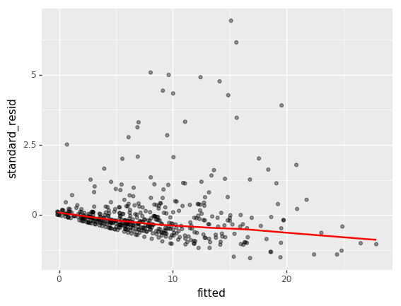

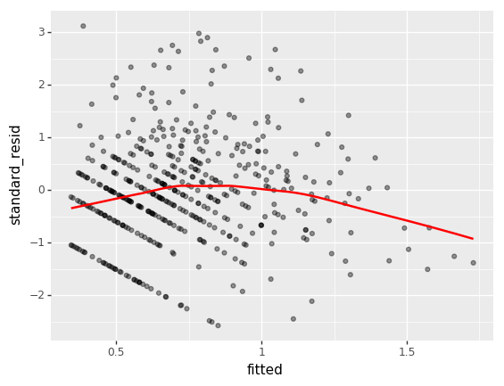

```python
# compare modelfit visually +Inspect Heteroscesticity, Linearity and Normality
for df in [data,ldata]:
    print((ggplot(df, aes(x='fitted', y='standard_resid'))
    + geom_point(alpha=0.4))
    + geom_smooth(color='red', se=False))
```

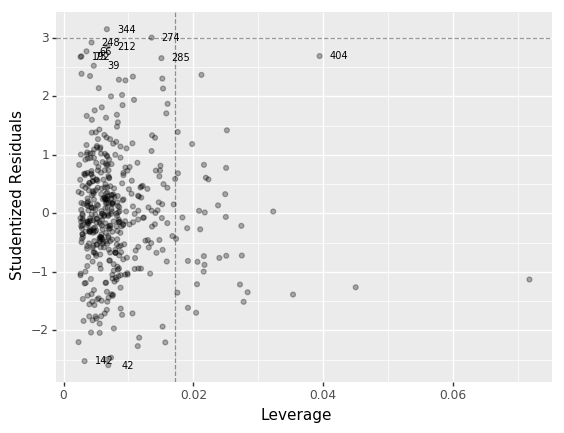

```python
#Create Influence plot
(ggplot(ldata, aes(x = 'hat_diag', y = 'student_resid'))
 + geom_point(alpha = 0.3)
 + geom_point(linfl, aes(x = 'hat_diag', y = 'student_resid'), color = 'red')
 + geom_text(loutlier, aes(label = 'index'), nudge_x = 0.003, size=7)
 + geom_vline(xintercept=2*ldata.hat_diag.mean(), linetype='dashed', alpha=0.4)
 + geom_hline(yintercept=3, alpha=0.4, linetype='dashed')
 + labs(x='Leverage', y='Studentized Residuals'))
```

```python
# percentage st.resid out of 2-2.5SD range
p = np.mean(abs(ldata['standard_resid'])>=2)
pp = np.mean(abs(ldata['standard_resid'])>=2.5)
print('{:.3f}% 2.0 SD \n{:.3f}% 2.5 SD'.format(p*100,pp*100))
```

```
6.452% 2.0 SD
2.581% 2.5 SD
```

###### Heteroscedasticity

```python
name = ['Lagrange multiplier statistic', 'p-value',
        'f-value', 'f p-value']
test = sms.het_white(lresults.resid,lresults.model.exog)
lzip(name, test)
```

```
[('Lagrange multiplier statistic', 8.7513050854335681),
 ('p-value', 0.46054052507849086),
 ('f-value', 0.96970598570829403),
 ('f p-value', 0.46437071667686092)]
```

```python
name = ['Lagrange multiplier statistic', 'p-value',
        'f-value', 'f p-value']
test = sms.het_breuschpagan(lresults.resid, lresults.model.exog)
lzip(name, test)
```

```
[('Lagrange multiplier statistic', 1.3933423294756682),
 ('p-value', 0.70709606574961414),
 ('f-value', 0.46183605811859191),
 ('f p-value', 0.70907121918891003)]
```

```python
name = ['F statistic', 'p-value']
test = sms.het_goldfeldquandt(lresults.resid, lresults.model.exog)
lzip(name, test)
```

```
[('F statistic', 0.83850645324091277), ('p-value', 0.9080322396100674)]
```